# R Notebook

```r
library(leaps)
```

1. Generate a data set with p=20 features, n=1000 observations, and an associated quantitative response vector generated according to the model

```r
set.seed(1)
x <- matrix(rnorm(1000 * 20), 1000, 20)
b <- rnorm(20)
b[3] <- 0
b[4] <- 0
b[9] <- 0
b[19] <- 0
b[10] <- 0
eps <- rnorm(1000)
y <- x %*% b + eps
```

2. Split your data set into a training set containing 100 observations and a test set containing 900 observations.

```r
train <- sample(seq(1000), 100, replace = FALSE)
test <- -train
x.train <- x[train, ]
x.test <- x[test, ]
y.train <- y[train]
y.test <- y[test]
```

3. Perform best subset selection on the training set, and plot the training set MSE associated with the best model of each size.

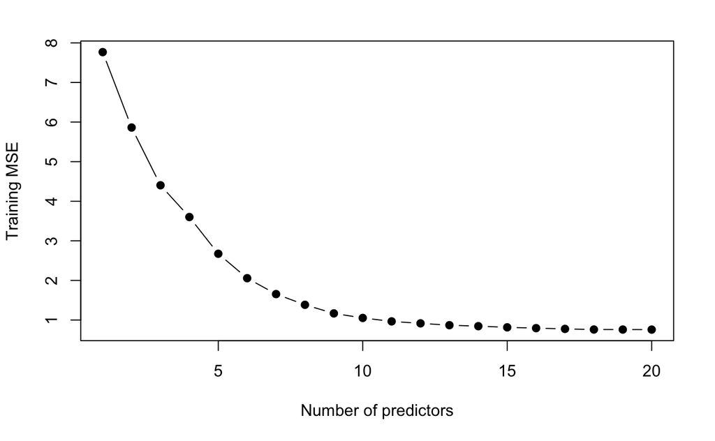

```r
data.train <- data.frame(y = y.train, x = x.train)
regfit.full <- regsubsets(y ~ ., data = data.train, nvmax = 20)
train.mat <- model.matrix(y ~ ., data = data.train, nvmax = 20)
val.errors <- rep(NA, 20)
for (i in 1:20) {
    coefi <- coef(regfit.full, id = i)
    pred <- train.mat[, names(coefi)] %*% coefi
    val.errors[i] <- mean((pred - y.train)^2)
}
plot(val.errors, xlab = "Number of predictors", ylab = "Training MSE", pch = 19, type = "b")
```

4. Plot the test MSE associated with the best model of each size.

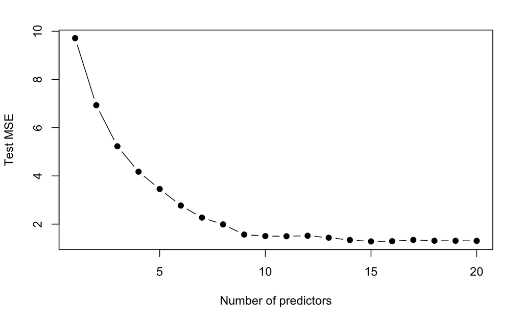

```r
data.test <- data.frame(y = y.test, x = x.test)
test.mat <- model.matrix(y ~ ., data = data.test, nvmax = 20)
val.errors <- rep(NA, 20)
for (i in 1:20) {
    coefi <- coef(regfit.full, id = i)
    pred <- test.mat[, names(coefi)] %*% coefi
    val.errors[i] <- mean((pred - y.test)^2)
}
plot(val.errors, xlab = "Number of predictors", ylab = "Test MSE", pch = 19, type = "b")
```

5. For which model size does the test set MSE take on its minimum value ? Comment on your results. It it takes on its minimum value for a model containing only an intercept or a model containing all the features, then play around with the way that you are generating the data in (a) until you come up with a scenario in which the test MSE is minimized for an intermediate model size.

```r
which.min(val.errors)
```

```
[1] 15
```

The 15-variables model has the smallest test MSE.

6. How does the model at which the test set MSE is minimized compare to the true model used to generate the data ? Comment on the coefficient values.

```r
coef(regfit.full, which.min(val.errors))
```

```
 (Intercept)          x.2          x.4          x.5          x.6          x.7          x.8
-0.003933937  0.359127426  0.202707344  1.036265913 -0.253843053 -1.282753293  0.691581077
        x.11         x.12         x.13         x.14         x.15         x.16         x.17
 0.895769881  0.526887865 -0.207638251 -0.507929833 -0.892604795 -0.343062241  0.184479252
        x.18         x.20
 1.646950451 -1.060191640
```

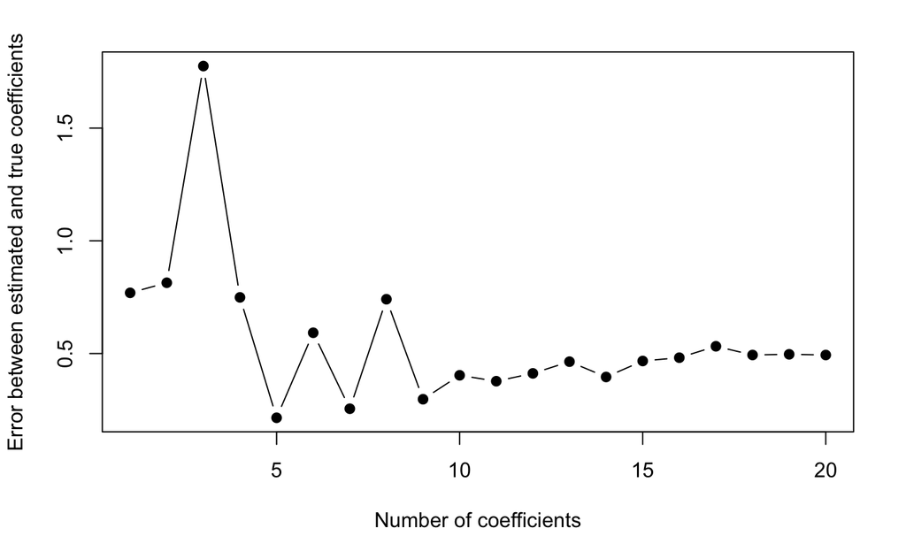

```r
val.errors <- rep(NA, 20)
x_cols = colnames(x, do.NULL = FALSE, prefix = "x.")
for (i in 1:20) {
    coefi <- coef(regfit.full, id = i)
    val.errors[i] <- sqrt(sum((b[x_cols %in% names(coefi)] - coefi[names(coefi) %in% x_cols])^2) + sum(b[!(x_cols %in% names(coefi))])^2)
}
plot(val.errors, xlab = "Number of coefficients", ylab = "Error between estimated and true coefficients", pch = 19, type = "b")
```